# Módulo 2 - completo

## Computação científica para biólogos

### Sumário

**Introdução: o porquê deste curso**

I.1 Apresentação  
I.2 Informática cada vez mais necessária  
I.3 As ferramentas

**Módulo 1: Ferramentas básicas**

1.1 - Linha de comando: Terminal  
1.2 - Editor de texto e IDE: Atom  
1.3 - Linguagem de Programação: Python

**Módulo 2: Bibliotecas e ambientes virtuais**

2.1 - Conda: Ambientes virtuais e instalação de dependências  
2.2 - Bibliotecas essenciais: Jupyter, Pandas e Matplotlib.  
2.3 - Analisando o conjunto Iris no Jupyter Notebook

**Módulo 3: Colaboração e boas práticas**

3.1 - Boas práticas em computação científica  
3.2 - Documentação e controle de versão: Git e GitHub  
3.3 - Como aprender programação: dicas para biólogos

-

## Módulo 2:

### 2.1 Conda: ambientes virtuais e dependências

### Pacotes e bibliotecas

Assim como o R, a capacidade do Python é enormemente expandida por conta da grande quantidade de pacotes e bibliotecas disponíveis. Alguns são essenciais para quem quer realizar análise de dados.

[figure not shown]

.

[Nesse tópico no site BioStars](https://www.biostars.org/p/50749/#50758), esse usuário apontou algumas ferramentas em Python que são úteis para biólogos.

Logo, é imprescindível aprender a baixar, instalar e rodar esses pacotes. Essa instalação é simples, mas é diferente de usar um "Install Wizard": geralmente é feita pela linha de comando.

[figure not shown]

Você pode até se safar instalando o RStudio usando um Install Wizard, mas para instalação de pacotes Python vai ter que recorrer ao Terminal.

Além disso, existe outra questão: muitos pacotes dependem de outros para funcionar, e todos dependem de ter uma instância de Python instalada. Pior, às vezes pacotes requerem versões **específicas** de outro pacote ou linguagem, e pacotes que requerem versões **diferentes** podem causar o que chamamos de um **conflito de dependência**.

### Ambientes virtuais: caixinhas no computador

Para instalarmos uma biblioteca, precisamos de um programa que faça isso para nós, um **gerenciador de pacotes**. Por sorte, o Python vem com um instalado de fábrica, o [`pip`](https://pip.pypa.io/en/stable/): pip installs packages. O `pip` faz download e instala pacotes disponíveis no [PyPI - Python Package Index](https://pypi.python.org/pypi), um repositório de bibliotecas aberto mantido pela Python Software Foundation. O `pip` funciona muito bem, no entanto queremos mais que isso.

Para isso instalamos o Anaconda, que é uma plataforma para ciência de dados que inclue um gerenciador de pacotes chamado [`conda`](https://conda.io/docs/index.html). Além de baixar e instalar pacotes, o `conda` também gerencia **ambientes virtuais**.

**Mas o que são e por que precisamos de ambientes virtuais?**

Ambientes virtuais (*virtual environments* ou *envs*), são como caixinhas em nosso computador na qual instalamos programas, pacotes, bibliotecas, ou dependências, e elas funcionam naquele ambiente, sem interferir com outras instalações fora desse ambiente.

**Por exemplo:**

Quando vamos baixar o Anaconda, podemos escolher entre Python versão 2.7 ou 3.4. Digamos que escolhemos a 3.4, por que é mais atualizada e compatível com a maioria dos programas. Porém, estamos fazendo um estudo de microbiologia e para analisar nossos dados, vamos precisar do [QIIME](http://qiime.org/), que requere a versão 2.7 do Python para rodar, e é incompatível com as versões 3.x. Além do Python, o QIIME requere versões específicas de diversas outras bibliotecas, que podem interferir com nosso ambiente **root** (nosso ambiente "global", sem nenhum ambiente virtual ativado).

A solução é **criar um ambiente virtual** com Python 2.7 instalado, e nesse ambiente instalamos as **dependências** necessárias para que o QIIME rode. O `conda` permite que façamos isso.

[figure not shown]

### Criando um ambiente virtual

Embora a instalação do Anaconda nos propicia o Anaconda Navigator, uma interface gráfica, vamos utilizar o `conda` pelo Terminal.

Nesse documento temos uma referência rápida dos comandos básicos do `conda`.

Para criar um novo ambiente, usamos o comando `conda create` junto do nome do ambiente e a versão de Python que desejamos.

`conda create --name qiime python=2.7`

Agora que temos um ambiente com a versão que precisamos, podemos instalar o QIIME e o restante de suas dependências.

Ativamos o novo ambiente com o comando: `source activate qiime`

### Instalando pacotes do Anaconda Cloud

Diferente do `pip`, o `conda` não baixa programas do [PyPI](https://pypi.python.org/pypi), e sim de outra base de dados, a [Anaconda Cloud.](https://anaconda.org/)

[figure not shown]

Esse repositório é muito útil pois fornece os pacotes disponíveis e os comandos para instalação.

[figure not shown]

Copiamos o comando e uma mensagem irá confirmar a instalação do QIIME e todas as dependências necessárias.

`conda install -c bioconda qiime`

Acontece que perdemos todas as nossas sequências, então não vamos precisar do QIIME. Vamos aprender sobre outras bibliotecas mais essenciais no momento. Remova o ambiente com o comando: `source deactivate` `conda remove -n qiime --all`

Vamos criar um novo repositório para fazer uma análise de dados mais simples. Além da versão do Python, podemos especificar outros pacotes para o `conda` instalar quando criar o ambiente:

`conda create -n tutorial Python=3 Pandas Matplotlib Jupyter`

Selecionamos Python 3, bem como as bibliotecas [Pandas](https://pandas.pydata.org/), [Matplotlib](https://matplotlib.org/), [Jupyter](http://jupyter.org/) e suas dependências.

Ativando o ambiente:

`source activate tutorial`

É importante aprender os diferentes comandos do `conda`. Outros gerenciadores de pacote como o `pip` também funcionam com comandos como `pip install <nome do pacote>`. Você pode utilizar o `pip` para instalar pacotes em ambientes criados pelo `conda`. Para ver os pacotes que estão no ambiente atual, use o comando `conda list`. Um sumários dos comandos do `conda` pode ser acessado nessa *cheat sheet*.

### 2.2 Bibliotecas essenciais: Pandas, Matplotlib e Jupyter.

É um equívoco comum, para quem está começando a aprender uma linguagem, pensar que o uso desta por si só vai levar ao resultado final do que se está buscando. Uma linguagem como Python, embora poderosa, necessita um conhecimento extenso para ser utilizada efetivamente sem o auxílio de pacotes externos.

Para tirar o máximo proveito de um conhecimento básico de Python, vamos alavancar a funcionalidade da linguagem por meio dessas três bibliotecas. Sua combinação vai nos possibilitar um ambiente simples mas efetivo para análise de dados. Se o nosso objetivo fosse outro, como por exemplo, desenvolvimento web, faríamos uso de outros *frameworks*, como [Flask](http://flask.pocoo.org/) ou [Django.](https://www.djangoproject.com/)

[figure not shown]

[Pandas](https://pandas.pydata.org/) é uma biblioteca de análise contendo ferramentas de análise de dados de fácil uso e alta performance. Vamos utilizar **métodos** dessa biblioteca para importar e manipular nossos dados.

[figure not shown]

[Matplotlib](https://matplotlib.org/) é uma biblioteca de plotagem inspirada no MATLAB, com a diferença de ser de graça e *open source*. Oferece uma variedade de ferramentas para plotar os dados que criamos com Pandas.

[figure not shown]

[Jupyter](http://jupyter.org/) é uma biblioteca muito interessante que nos fornece o [Jupyter Notebook](https://github.com/jupyter/jupyter/wiki/A-gallery-of-interesting-Jupyter-Notebooks), uma ferramenta muito útil para organizar um projeto de análise de dados.

Um arquivo Jupyter Notebook permite a *execução de código* junto com texto MarkDown, como html. Vamos realizar nossa análise com Pandas, plotar com Matplotlib e anotar e organizar tudo com anotações utilizando o Jupyter Notebook.

Assim como o arquivo Python - primeiros comandos.html, a continuação desta página foi renderizado a partir de um arquivo Notebook. Acompanhe por aqui ou abra o arquivo notebooks/Módulo 2 - continuação.ipynb

No Terminal, digite `Jupyter Notebook` para abrir uma página no seu navegador web.

-

### Módulo 2 - continuação em .html

### 2.3 Plotando dados no Jupyter Notebook

Continuamos o Módulo 2 em um Jupyter Notebook. Essas páginas possibilitam a disposição de texto MarkDown (como este) e código Python (algumas caixas abaixo). Vamos anotar nossa análise com porções de MarkDown, mas o que cada comando específico faz será anotado com comentários no próprio código. Os comentários são precedidos do caracter '#' que indica que aquela porção é um comentário e portanto não será executado como código. Diferente de uma IDE, os Notebooks **não são** ambientes ideais para testes, experimentos ou instalação de programas, mas são excelentes para descrição e organização de análises. Os Notebooks suportam uma variedade de linguagens, inclusive bash, então é possível comandar o Terminal por aqui. Basta botar um `!` na frente do comando.

```python
cd ..
```

```
/Users/viniWS/Bio/tccvini/tutorial_v2
```

```python
!ls
```

```
Introdução.html                  markdown
Módulo 1.html                    notebooks
Python - Primeiros comandos.html papers
README.md                        screens
data
```

```python
# Se nosso ambiente não estiver ativo podemos rodar
!source activate tutorial
```

Há muito o que se fazer com os Jupyter Notebooks, e é muito bom ficar confortável com eles! Bom, mas o que queremos agora é usa-los para realizar uma análise de dados que poderia caber a qualquer estudante de biologia. Vamos usar o famoso conjunto de dados Iris, que está em um arquivo .csv em nossa pasta local. Arquivos .csv ou .tsv (*comma* ou *tab-separated values*) são arquivos de texto usados para representar tabelas. Uma tabela do Excel, por exemplo, pode ser exportada como .csv.

O uso do **Pandas** possibilita importar a tabela com os dados diretamente em um objeto do tipo *Dataframe*. Vamos importar a biblioteca Pandas com o comando `import` e abreviar ela como `pd`. Também vamos importar a biblioteca `matplotlib.pyplot` e abreviar como `plt`. Ambas essas abreviações são universais para esses pacotes. A razão que importamos `matplotlib.pyplot` ao invés de `matplotlib` é porque `pyplot` é uma **API**, um programa que serve como uma interface para 'conectar' os pacotes Pandas e Matplotlib.

```python
# Importando as bibliotecas e suas respectivas abreviações
import pandas as pd
import matplotlib.pyplot as plt
```

Agora já temos todos os métodos dessas bibliotecas à nossa disposição. Só falta importar os dados. Para isso, o Pandas oferece o método read_csv, que converte um arquivo .csv em dataframe. Vamos armazenar esse dataframe em uma variável `iris`.

```python
# Vamos armazenar esse objeto Pandas em uma variável 'iris'
iris = pd.read_csv('data/iris.csv')
print(iris)
```

```
     SepalLengthCm  SepalWidthCm  PetalLengthCm  PetalWidthCm         species
0              5.1           3.5            1.4           0.2     Iris-setosa
1              4.9           3.0            1.4           0.2     Iris-setosa
2              4.7           3.2            1.3           0.2     Iris-setosa
3              4.6           3.1            1.5           0.2     Iris-setosa
4              5.0           3.6            1.4           0.2     Iris-setosa
5              5.4           3.9            1.7           0.4     Iris-setosa
6              4.6           3.4            1.4           0.3     Iris-setosa
7              5.0           3.4            1.5           0.2     Iris-setosa
8              4.4           2.9            1.4           0.2     Iris-setosa
9              4.9           3.1            1.5           0.1     Iris-setosa
10             5.4           3.7            1.5           0.2     Iris-setosa
11             4.8           3.4            1.6           0.2     Iris-setosa
12             4.8           3.0            1.4           0.1     Iris-setosa
13             4.3           3.0            1.1           0.1     Iris-setosa
```

[output cut: 49 more lines]

```python
# Quando verificamos que tipo de dado é 'iris', vemos que o Pandas já converte o arquivo .csv em um Dataframe.
type(iris)
```

```
pandas.core.frame.DataFrame
```

```python
# Outra possibilidade de visualização é com os comandos head() e tail() ou describe().
iris.head()
```

|  | SepalLengthCm | SepalWidthCm | PetalLengthCm | PetalWidthCm | species |
| --- | --- | --- | --- | --- | --- |
| 0 | 5.1 | 3.5 | 1.4 | 0.2 | Iris-setosa |
| 1 | 4.9 | 3.0 | 1.4 | 0.2 | Iris-setosa |
| 2 | 4.7 | 3.2 | 1.3 | 0.2 | Iris-setosa |
| 3 | 4.6 | 3.1 | 1.5 | 0.2 | Iris-setosa |
| 4 | 5.0 | 3.6 | 1.4 | 0.2 | Iris-setosa |

```python
iris.tail()
```

|  | SepalLengthCm | SepalWidthCm | PetalLengthCm | PetalWidthCm | species |
| --- | --- | --- | --- | --- | --- |
| 145 | 6.7 | 3.0 | 5.2 | 2.3 | Iris-virginica |
| 146 | 6.3 | 2.5 | 5.0 | 1.9 | Iris-virginica |
| 147 | 6.5 | 3.0 | 5.2 | 2.0 | Iris-virginica |
| 148 | 6.2 | 3.4 | 5.4 | 2.3 | Iris-virginica |
| 149 | 5.9 | 3.0 | 5.1 | 1.8 | Iris-virginica |

```python
iris.describe() # species não foi incluído pois contém strings, e não floats.
```

|  | SepalLengthCm | SepalWidthCm | PetalLengthCm | PetalWidthCm |
| --- | --- | --- | --- | --- |
| count | 150.000000 | 150.000000 | 150.000000 | 150.000000 |
| mean | 5.843333 | 3.054000 | 3.758667 | 1.198667 |
| std | 0.828066 | 0.433594 | 1.764420 | 0.763161 |
| min | 4.300000 | 2.000000 | 1.000000 | 0.100000 |
| 25% | 5.100000 | 2.800000 | 1.600000 | 0.300000 |
| 50% | 5.800000 | 3.000000 | 4.350000 | 1.300000 |
| 75% | 6.400000 | 3.300000 | 5.100000 | 1.800000 |
| max | 7.900000 | 4.400000 | 6.900000 | 2.500000 |

```python
# Podemos selecionar colunas específicas com colchetes e a string que dá nome à coluna.
iris['species']
```

```
0         Iris-setosa
1         Iris-setosa
2         Iris-setosa
3         Iris-setosa
4         Iris-setosa
5         Iris-setosa
6         Iris-setosa
7         Iris-setosa
8         Iris-setosa
9         Iris-setosa
10        Iris-setosa
11        Iris-setosa
12        Iris-setosa
13        Iris-setosa
14        Iris-setosa
```

[output cut: 47 more lines]

```python
# Podemos combinar com head():
iris['species'].head()
```

```
0    Iris-setosa
1    Iris-setosa
2    Iris-setosa
3    Iris-setosa
4    Iris-setosa
Name: species, dtype: object
```

```python
# ou com iloc[], que permite escolher as linhas:
iris['species'].iloc[10:51]
```

```
10        Iris-setosa
11        Iris-setosa
12        Iris-setosa
13        Iris-setosa
14        Iris-setosa
15        Iris-setosa
16        Iris-setosa
17        Iris-setosa
18        Iris-setosa
19        Iris-setosa
20        Iris-setosa
21        Iris-setosa
22        Iris-setosa
23        Iris-setosa
24        Iris-setosa
```

[output cut: 27 more lines]

Utilizamos o Pandas para importar nosso arquivo .csv em um *dataframe* armazenado na variável `iris`. Além de importar, o Pandas também possui o método `plot()`. Escolhemos nossos eixos bem como o tipo de Plot.

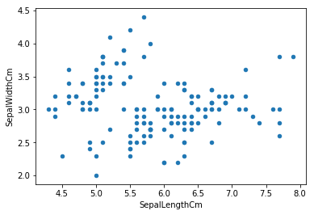

```python
# Vamos tentar um scatter plot simples com o método plot(). Repare nos parâmetros definindo x, y e 'kind'
iris.plot(x='SepalLengthCm', y='SepalWidthCm', kind = 'scatter')
```

[output not shown]

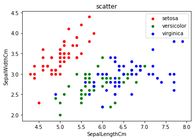

```python
# Agora um pouco mais sofisticado, com cores.
# ax é um objeto da biblioteca Matplotlib, que corresponde a um eixo ou porção de uma figura
# Vamos projetar três plots, um para cada espécie, porém todos no mesmo eixo (ax)
# Também é possível adicionar labels e um título para o eixo.

ax = iris[iris.species=='Iris-setosa'].plot.scatter(x='SepalLengthCm', y='SepalWidthCm',
                                                    color='red', label='setosa')
iris[iris.species=='Iris-versicolor'].plot.scatter(x='SepalLengthCm', y='SepalWidthCm',
                                                color='green', label='versicolor', ax=ax)
iris[iris.species=='Iris-virginica'].plot.scatter(x='SepalLengthCm', y='SepalWidthCm',
                                                color='blue', label='virginica', ax=ax)
ax.set_title("scatter")
```

Esse último snippet foi retirado [deste notebook Kaggle.](https://www.kaggle.com/xuhewen/iris-dataset-visualization-and-machine-learning)